# Risk Factor Analysis

## Outcome Variable

**Outcome Variable:** stunted

## Predictor Variables

**Intervention Variable:** cleanck

**Adjustment Set:**

- arm
- sex
- W_mage
- meducyrs
- feducyrs
- hhwealth_quart
- W_nrooms
- W_nhh
- W_nchldlt5
- trth2o
- impfloor
- delta_meducyrs
- delta_feducyrs
- delta_hhwealth_quart
- delta_W_nrooms
- delta_W_nhh
- delta_W_nchldlt5
- delta_trth2o
- delta_impfloor

## Stratifying Variables

The analysis was stratified on these variable(s):

- agecat
- studyid
- country

## Data Summary

| agecat | studyid | country | cleanck | stunted | n_cell | n |
| --- | --- | --- | --- | --- | --- | --- |
| Birth | ki0047075b-MAL-ED | PERU | 0 | 0 | 1 | 2 |
| Birth | ki0047075b-MAL-ED | PERU | 1 | 0 | 1 | 2 |
| Birth | ki0047075b-MAL-ED | SOUTH AFRICA | 0 | 0 | 1 | 2 |
| Birth | ki0047075b-MAL-ED | SOUTH AFRICA | 0 | 1 | 0 | 2 |
| Birth | ki0047075b-MAL-ED | SOUTH AFRICA | 1 | 0 | 0 | 2 |
| Birth | ki0047075b-MAL-ED | SOUTH AFRICA | 1 | 1 | 1 | 2 |
| 6 months | ki0047075b-MAL-ED | SOUTH AFRICA | 1 | 0 | 1 | 1 |
| 24 months | ki0047075b-MAL-ED | SOUTH AFRICA | 1 | 0 | 1 | 1 |
| 6 months | ki1000108-CMC-V-BCS-2002 | INDIA | 0 | 0 | 135 | 369 |
| 6 months | ki1000108-CMC-V-BCS-2002 | INDIA | 0 | 1 | 71 | 369 |
| 6 months | ki1000108-CMC-V-BCS-2002 | INDIA | 1 | 0 | 123 | 369 |
| 6 months | ki1000108-CMC-V-BCS-2002 | INDIA | 1 | 1 | 40 | 369 |
| 24 months | ki1000108-CMC-V-BCS-2002 | INDIA | 0 | 0 | 39 | 372 |
| 24 months | ki1000108-CMC-V-BCS-2002 | INDIA | 0 | 1 | 170 | 372 |
| 24 months | ki1000108-CMC-V-BCS-2002 | INDIA | 1 | 0 | 67 | 372 |
| 24 months | ki1000108-CMC-V-BCS-2002 | INDIA | 1 | 1 | 96 | 372 |
| Birth | ki1000108-CMC-V-BCS-2002 | INDIA | 0 | 0 | 40 | 90 |
| Birth | ki1000108-CMC-V-BCS-2002 | INDIA | 0 | 1 | 12 | 90 |
| Birth | ki1000108-CMC-V-BCS-2002 | INDIA | 1 | 0 | 34 | 90 |
| Birth | ki1000108-CMC-V-BCS-2002 | INDIA | 1 | 1 | 4 | 90 |
| 6 months | ki1000108-IRC | INDIA | 0 | 0 | 119 | 398 |
| 6 months | ki1000108-IRC | INDIA | 0 | 1 | 49 | 398 |
| 6 months | ki1000108-IRC | INDIA | 1 | 0 | 181 | 398 |
| 6 months | ki1000108-IRC | INDIA | 1 | 1 | 49 | 398 |
| 24 months | ki1000108-IRC | INDIA | 0 | 0 | 89 | 400 |
| 24 months | ki1000108-IRC | INDIA | 0 | 1 | 80 | 400 |
| 24 months | ki1000108-IRC | INDIA | 1 | 0 | 144 | 400 |
| 24 months | ki1000108-IRC | INDIA | 1 | 1 | 87 | 400 |
| Birth | ki1000108-IRC | INDIA | 0 | 0 | 138 | 378 |
| Birth | ki1000108-IRC | INDIA | 0 | 1 | 22 | 378 |
| Birth | ki1000108-IRC | INDIA | 1 | 0 | 197 | 378 |
| Birth | ki1000108-IRC | INDIA | 1 | 1 | 21 | 378 |
| 6 months | ki1017093b-PROVIDE | BANGLADESH | 0 | 0 | 76 | 583 |
| 6 months | ki1017093b-PROVIDE | BANGLADESH | 0 | 1 | 25 | 583 |
| 6 months | ki1017093b-PROVIDE | BANGLADESH | 1 | 0 | 413 | 583 |
| 6 months | ki1017093b-PROVIDE | BANGLADESH | 1 | 1 | 69 | 583 |
| 24 months | ki1017093b-PROVIDE | BANGLADESH | 0 | 0 | 49 | 577 |
| 24 months | ki1017093b-PROVIDE | BANGLADESH | 0 | 1 | 49 | 577 |
| 24 months | ki1017093b-PROVIDE | BANGLADESH | 1 | 0 | 338 | 577 |
| 24 months | ki1017093b-PROVIDE | BANGLADESH | 1 | 1 | 141 | 577 |
| Birth | ki1017093c-NIH-Crypto | BANGLADESH | 0 | 0 | 6 | 20 |
| Birth | ki1017093c-NIH-Crypto | BANGLADESH | 0 | 1 | 2 | 20 |
| Birth | ki1017093c-NIH-Crypto | BANGLADESH | 1 | 0 | 11 | 20 |
| Birth | ki1017093c-NIH-Crypto | BANGLADESH | 1 | 1 | 1 | 20 |
| 6 months | ki1017093c-NIH-Crypto | BANGLADESH | 0 | 0 | 179 | 545 |
| 6 months | ki1017093c-NIH-Crypto | BANGLADESH | 0 | 1 | 37 | 545 |
| 6 months | ki1017093c-NIH-Crypto | BANGLADESH | 1 | 0 | 264 | 545 |
| 6 months | ki1017093c-NIH-Crypto | BANGLADESH | 1 | 1 | 65 | 545 |
| 24 months | ki1017093c-NIH-Crypto | BANGLADESH | 0 | 0 | 167 | 410 |
| 24 months | ki1017093c-NIH-Crypto | BANGLADESH | 0 | 1 | 44 | 410 |
| 24 months | ki1017093c-NIH-Crypto | BANGLADESH | 1 | 0 | 156 | 410 |
| 24 months | ki1017093c-NIH-Crypto | BANGLADESH | 1 | 1 | 43 | 410 |
| 6 months | ki1113344-GMS-Nepal | NEPAL | 0 | 0 | 389 | 504 |
| 6 months | ki1113344-GMS-Nepal | NEPAL | 0 | 1 | 107 | 504 |
| 6 months | ki1113344-GMS-Nepal | NEPAL | 1 | 0 | 8 | 504 |
| 6 months | ki1113344-GMS-Nepal | NEPAL | 1 | 1 | 0 | 504 |
| 24 months | ki1113344-GMS-Nepal | NEPAL | 0 | 0 | 237 | 446 |
| 24 months | ki1113344-GMS-Nepal | NEPAL | 0 | 1 | 202 | 446 |
| 24 months | ki1113344-GMS-Nepal | NEPAL | 1 | 0 | 7 | 446 |
| 24 months | ki1113344-GMS-Nepal | NEPAL | 1 | 1 | 0 | 446 |

The following strata were considered:

- agecat: 24 months, studyid: ki0047075b-MAL-ED, country: SOUTH AFRICA
- agecat: 24 months, studyid: ki1000108-CMC-V-BCS-2002, country: INDIA
- agecat: 24 months, studyid: ki1000108-IRC, country: INDIA
- agecat: 24 months, studyid: ki1017093b-PROVIDE, country: BANGLADESH
- agecat: 24 months, studyid: ki1017093c-NIH-Crypto, country: BANGLADESH
- agecat: 24 months, studyid: ki1113344-GMS-Nepal, country: NEPAL
- agecat: 6 months, studyid: ki0047075b-MAL-ED, country: SOUTH AFRICA
- agecat: 6 months, studyid: ki1000108-CMC-V-BCS-2002, country: INDIA
- agecat: 6 months, studyid: ki1000108-IRC, country: INDIA
- agecat: 6 months, studyid: ki1017093b-PROVIDE, country: BANGLADESH
- agecat: 6 months, studyid: ki1017093c-NIH-Crypto, country: BANGLADESH
- agecat: 6 months, studyid: ki1113344-GMS-Nepal, country: NEPAL
- agecat: Birth, studyid: ki0047075b-MAL-ED, country: PERU
- agecat: Birth, studyid: ki0047075b-MAL-ED, country: SOUTH AFRICA
- agecat: Birth, studyid: ki1000108-CMC-V-BCS-2002, country: INDIA
- agecat: Birth, studyid: ki1000108-IRC, country: INDIA
- agecat: Birth, studyid: ki1017093c-NIH-Crypto, country: BANGLADESH

### Dropped Strata

Some strata were dropped due to rare outcomes:

- agecat: Birth, studyid: ki0047075b-MAL-ED, country: PERU
- agecat: Birth, studyid: ki0047075b-MAL-ED, country: SOUTH AFRICA
- agecat: 6 months, studyid: ki0047075b-MAL-ED, country: SOUTH AFRICA
- agecat: 24 months, studyid: ki0047075b-MAL-ED, country: SOUTH AFRICA
- agecat: Birth, studyid: ki1000108-CMC-V-BCS-2002, country: INDIA
- agecat: Birth, studyid: ki1017093c-NIH-Crypto, country: BANGLADESH
- agecat: 6 months, studyid: ki1113344-GMS-Nepal, country: NEPAL
- agecat: 24 months, studyid: ki1113344-GMS-Nepal, country: NEPAL

## Methods Detail

We’re interested in the causal parameters $E[Y_a]$ for all values of $a \in \mathcal{A}$. These parameters represent the mean outcome if, possibly contrary to fact, we intervened to set all units to have $A=a$. Under the randomization and positivity assumptions, these are identified by the statistical parameters $\psi_a=E_W[E_{Y|A,W}(Y|A=a,W)]$. In addition, we’re interested in the mean of $Y$, $E[Y]$ under no intervention (the observed mean). We will estimate these parameters by using SuperLearner to fit the relevant likelihood factors – $E_{Y|A,W}(Y|A=a,W)$ and $p(A=a|W)$, and then updating our likelihood fit using a joint TMLE.

For unadjusted analyses ($W=\{\}$), initial likelihoods were estimated using Lrnr_glm to estimate the simple $E(Y|A)$ and Lrnr_mean to estimate $p(A)$. For adjusted analyses, a small library containing Lrnr_glmnet, Lrnr_xgboost, and Lrnr_mean was used.

Having estimated these parameters, we will then use the delta method to estimate relative risks and attributable risks relative to a prespecified baseline level of $A$.

# Results Detail

## Results Plots

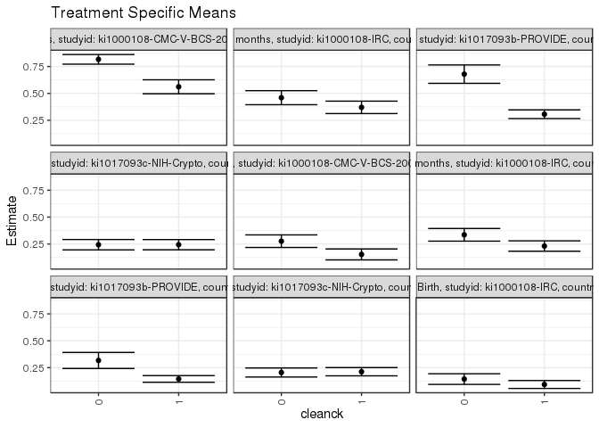

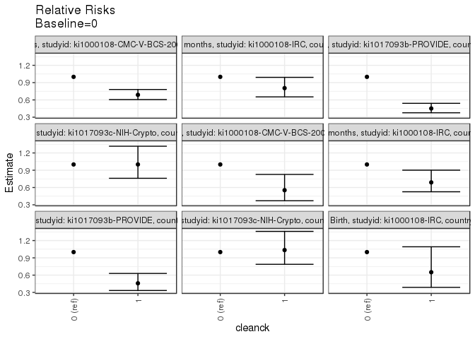

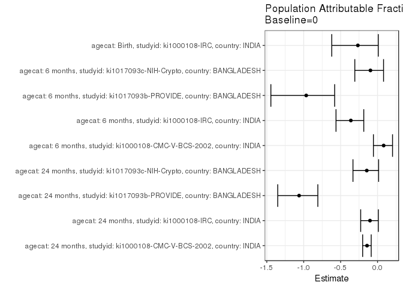

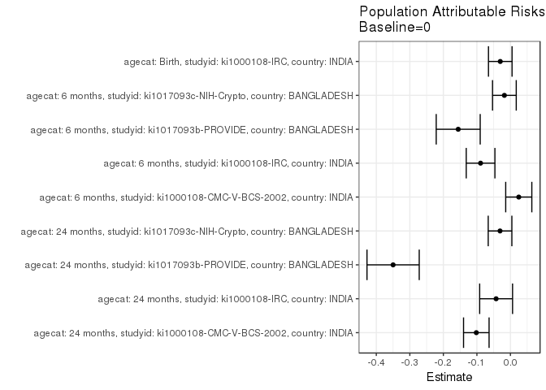

## Results Table

### Parameter: TSM

| agecat | studyid | country | intervention_level | baseline_level | estimate | ci_lower | ci_upper |
| --- | --- | --- | --- | --- | --- | --- | --- |
| Birth | ki1000108-IRC | INDIA | 0 | NA | 0.1440710 | 0.0946000 | 0.1935420 |
| Birth | ki1000108-IRC | INDIA | 1 | NA | 0.0936886 | 0.0569744 | 0.1304029 |
| 6 months | ki1000108-CMC-V-BCS-2002 | INDIA | 0 | NA | 0.2759567 | 0.2175097 | 0.3344036 |
| 6 months | ki1000108-CMC-V-BCS-2002 | INDIA | 1 | NA | 0.1528089 | 0.1019694 | 0.2036483 |
| 6 months | ki1000108-IRC | INDIA | 0 | NA | 0.3352670 | 0.2765874 | 0.3939467 |
| 6 months | ki1000108-IRC | INDIA | 1 | NA | 0.2308404 | 0.1826516 | 0.2790291 |
| 6 months | ki1017093b-PROVIDE | BANGLADESH | 0 | NA | 0.3169801 | 0.2423592 | 0.3916011 |
| 6 months | ki1017093b-PROVIDE | BANGLADESH | 1 | NA | 0.1452781 | 0.1141696 | 0.1763865 |
| 6 months | ki1017093c-NIH-Crypto | BANGLADESH | 0 | NA | 0.2051670 | 0.1629747 | 0.2473593 |
| 6 months | ki1017093c-NIH-Crypto | BANGLADESH | 1 | NA | 0.2123508 | 0.1741392 | 0.2505625 |
| 24 months | ki1000108-CMC-V-BCS-2002 | INDIA | 0 | NA | 0.8168011 | 0.7720113 | 0.8615909 |
| 24 months | ki1000108-CMC-V-BCS-2002 | INDIA | 1 | NA | 0.5617075 | 0.4968996 | 0.6265155 |
| 24 months | ki1000108-IRC | INDIA | 0 | NA | 0.4601966 | 0.3950099 | 0.5253834 |
| 24 months | ki1000108-IRC | INDIA | 1 | NA | 0.3702049 | 0.3123744 | 0.4280355 |
| 24 months | ki1017093b-PROVIDE | BANGLADESH | 0 | NA | 0.6791677 | 0.5935355 | 0.7647999 |
| 24 months | ki1017093b-PROVIDE | BANGLADESH | 1 | NA | 0.3065095 | 0.2660487 | 0.3469704 |
| 24 months | ki1017093c-NIH-Crypto | BANGLADESH | 0 | NA | 0.2431818 | 0.1950594 | 0.2913041 |
| 24 months | ki1017093c-NIH-Crypto | BANGLADESH | 1 | NA | 0.2433313 | 0.1959820 | 0.2906805 |

### Parameter: E(Y)

| agecat | studyid | country | intervention_level | baseline_level | estimate | ci_lower | ci_upper |
| --- | --- | --- | --- | --- | --- | --- | --- |
| Birth | ki1000108-IRC | INDIA | NA | NA | 0.1137566 | 0.0817056 | 0.1458077 |
| 6 months | ki1000108-CMC-V-BCS-2002 | INDIA | NA | NA | 0.3008130 | 0.2539566 | 0.3476694 |
| 6 months | ki1000108-IRC | INDIA | NA | NA | 0.2462312 | 0.2038529 | 0.2886094 |
| 6 months | ki1017093b-PROVIDE | BANGLADESH | NA | NA | 0.1612350 | 0.1313580 | 0.1911120 |
| 6 months | ki1017093c-NIH-Crypto | BANGLADESH | NA | NA | 0.1871560 | 0.1543801 | 0.2199318 |
| 24 months | ki1000108-CMC-V-BCS-2002 | INDIA | NA | NA | 0.7150538 | 0.6691221 | 0.7609854 |
| 24 months | ki1000108-IRC | INDIA | NA | NA | 0.4175000 | 0.3691120 | 0.4658880 |
| 24 months | ki1017093b-PROVIDE | BANGLADESH | NA | NA | 0.3292894 | 0.2909105 | 0.3676684 |
| 24 months | ki1017093c-NIH-Crypto | BANGLADESH | NA | NA | 0.2121951 | 0.1725707 | 0.2518196 |

### Parameter: RR

| agecat | studyid | country | intervention_level | baseline_level | estimate | ci_lower | ci_upper |
| --- | --- | --- | --- | --- | --- | --- | --- |
| Birth | ki1000108-IRC | INDIA | 0 | 0 | 1.0000000 | 1.0000000 | 1.0000000 |
| Birth | ki1000108-IRC | INDIA | 1 | 0 | 0.6502950 | 0.3873127 | 1.0918403 |
| 6 months | ki1000108-CMC-V-BCS-2002 | INDIA | 0 | 0 | 1.0000000 | 1.0000000 | 1.0000000 |
| 6 months | ki1000108-CMC-V-BCS-2002 | INDIA | 1 | 0 | 0.5537422 | 0.3705458 | 0.8275103 |
| 6 months | ki1000108-IRC | INDIA | 0 | 0 | 1.0000000 | 1.0000000 | 1.0000000 |
| 6 months | ki1000108-IRC | INDIA | 1 | 0 | 0.6885270 | 0.5260468 | 0.9011924 |
| 6 months | ki1017093b-PROVIDE | BANGLADESH | 0 | 0 | 1.0000000 | 1.0000000 | 1.0000000 |
| 6 months | ki1017093b-PROVIDE | BANGLADESH | 1 | 0 | 0.4583192 | 0.3337562 | 0.6293711 |
| 6 months | ki1017093c-NIH-Crypto | BANGLADESH | 0 | 0 | 1.0000000 | 1.0000000 | 1.0000000 |
| 6 months | ki1017093c-NIH-Crypto | BANGLADESH | 1 | 0 | 1.0350146 | 0.7879587 | 1.3595322 |
| 24 months | ki1000108-CMC-V-BCS-2002 | INDIA | 0 | 0 | 1.0000000 | 1.0000000 | 1.0000000 |
| 24 months | ki1000108-CMC-V-BCS-2002 | INDIA | 1 | 0 | 0.6876919 | 0.6056599 | 0.7808346 |
| 24 months | ki1000108-IRC | INDIA | 0 | 0 | 1.0000000 | 1.0000000 | 1.0000000 |
| 24 months | ki1000108-IRC | INDIA | 1 | 0 | 0.8044495 | 0.6527662 | 0.9913794 |
| 24 months | ki1017093b-PROVIDE | BANGLADESH | 0 | 0 | 1.0000000 | 1.0000000 | 1.0000000 |
| 24 months | ki1017093b-PROVIDE | BANGLADESH | 1 | 0 | 0.4513017 | 0.3766237 | 0.5407871 |
| 24 months | ki1017093c-NIH-Crypto | BANGLADESH | 0 | 0 | 1.0000000 | 1.0000000 | 1.0000000 |
| 24 months | ki1017093c-NIH-Crypto | BANGLADESH | 1 | 0 | 1.0006149 | 0.7605011 | 1.3165401 |

### Parameter: PAR

| agecat | studyid | country | intervention_level | baseline_level | estimate | ci_lower | ci_upper |
| --- | --- | --- | --- | --- | --- | --- | --- |
| Birth | ki1000108-IRC | INDIA | 0 | NA | -0.0303144 | -0.0654712 | 0.0048425 |
| 6 months | ki1000108-CMC-V-BCS-2002 | INDIA | 0 | NA | 0.0248564 | -0.0140773 | 0.0637900 |
| 6 months | ki1000108-IRC | INDIA | 0 | NA | -0.0890359 | -0.1317953 | -0.0462764 |
| 6 months | ki1017093b-PROVIDE | BANGLADESH | 0 | NA | -0.1557451 | -0.2213308 | -0.0901594 |
| 6 months | ki1017093c-NIH-Crypto | BANGLADESH | 0 | NA | -0.0180110 | -0.0533708 | 0.0173487 |
| 24 months | ki1000108-CMC-V-BCS-2002 | INDIA | 0 | NA | -0.1017474 | -0.1398133 | -0.0636814 |
| 24 months | ki1000108-IRC | INDIA | 0 | NA | -0.0426966 | -0.0917424 | 0.0063491 |
| 24 months | ki1017093b-PROVIDE | BANGLADESH | 0 | NA | -0.3498783 | -0.4277684 | -0.2719881 |
| 24 months | ki1017093c-NIH-Crypto | BANGLADESH | 0 | NA | -0.0309866 | -0.0662447 | 0.0042714 |

### Parameter: PAF

| agecat | studyid | country | intervention_level | baseline_level | estimate | ci_lower | ci_upper |
| --- | --- | --- | --- | --- | --- | --- | --- |
| Birth | ki1000108-IRC | INDIA | 0 | NA | -0.2664845 | -0.6203080 | 0.0100753 |
| 6 months | ki1000108-CMC-V-BCS-2002 | INDIA | 0 | NA | 0.0826306 | -0.0559094 | 0.2029935 |
| 6 months | ki1000108-IRC | INDIA | 0 | NA | -0.3615946 | -0.5624725 | -0.1865425 |
| 6 months | ki1017093b-PROVIDE | BANGLADESH | 0 | NA | -0.9659512 | -1.4447142 | -0.5809473 |
| 6 months | ki1017093c-NIH-Crypto | BANGLADESH | 0 | NA | -0.0962355 | -0.3079646 | 0.0812196 |
| 24 months | ki1000108-CMC-V-BCS-2002 | INDIA | 0 | NA | -0.1422933 | -0.2016603 | -0.0858593 |
| 24 months | ki1000108-IRC | INDIA | 0 | NA | -0.1022674 | -0.2282640 | 0.0108043 |
| 24 months | ki1017093b-PROVIDE | BANGLADESH | 0 | NA | -1.0625250 | -1.3518697 | -0.8087777 |
| 24 months | ki1017093c-NIH-Crypto | BANGLADESH | 0 | NA | -0.1460290 | -0.3328925 | 0.0146373 |